# CITRUS function usage

Meng Wang

2018-10-01

## Purpose

This document demonstrates the usage of a few convenient wrapper functions for CITRUS. As an example, we use it to analyze the CLL dataset and find differential clusters between NR and CR.

Two inputs are needed for all the analysis, the FCS files and corresponding patient label (e.g. responses). First, we specify the path to FCS file of interest and associated outcome. In this example, we selected the fcs files of CD8 pregated cells from 7 CR and 24 NR CLL patients. Here is a sanity check on the outcome data counts and the list of patient ID:

```r
outcome_path <- "/Volumes/pdcs/szmamie/data/20180929_CLL_reanalysis/CLL_outcomes.csv"
TCD_dir_path <- "/Volumes/pdcs/szmamie/data/metaAnalysis/Apheresis/CD8/TCD/"
TCD_file_list <- list.files(file.path(TCD_dir_path, "8_20160823_ALL_CLL/"), pattern="fcs", full=T)
TCD_file_list_pid <- unname(sapply(TCD_file_list, filename_to_pid))
outcome_data <- readr::read_csv(outcome_path)
patient_selected <- outcome_data$lulian_outcome %in% c('CR', 'NR')
TCD_file_selected <- TCD_file_list[TCD_file_list_pid %in% outcome_data$pid[patient_selected]]
kableExtra::kable_styling(kableExtra::kable(outcome_data[patient_selected,]))
```

| pid | disease | lulian_outcome | mamie_last_response | mamie_best_response |
| --- | --- | --- | --- | --- |
| UPCC03712-01 | CLL | NR | PD | NR |
| UPCC03712-03 | CLL | CR | CRi | CR |
| UPCC03712-04 | CLL | CR | CRi | CRi |
| UPCC03712-06 | CLL | CR | CR | CR |
| UPCC03712-08 | CLL | NR | NR | NR |
| UPCC03712-09 | CLL | NR | PD | PD |
| UPCC03712-11 | CLL | NR | PD | NR |
| UPCC03712-12 | CLL | NR | PD | NR |
| UPCC03712-14 | CLL | NR | NR | NR |
| UPCC03712-17 | CLL | NR | NR | NR |
| UPCC03712-20 | CLL | NR | NR | NR |
| UPCC03712-24 | CLL | NR | PD | PD |
| UPCC03712-25 | CLL | NR | NR | NR |
| UPCC03712-26 | CLL | NR | PD | NR |
| UPCC03712-30 | CLL | NR | PD | NR |
| UPCC03712-34 | CLL | NR | NR | NR |
| UPCC03712-35 | CLL | NR | NR | NR |
| UPCC03712-37 | CLL | NR | NR | NR |
| UPCC03712-39 | CLL | NR | PD | NR |
| UPCC03712-40 | CLL | NR | PD | NR |
| UPCC03712-45 | CLL | CR | CRi | CR |
| UPCC03712-46 | CLL | NR | PD | PD |
| UPCC03712-51 | CLL | NR | PD | PD |
| UPCC03712-58 | CLL | CR | CRi | CR |
| UPCC04409-07 | CLL | NR | NR | NR |
| UPCC04409-09 | CLL | CR | PR | PR |
| UPCC04409-10 | CLL | CR | CR | CR |
| UPCC04409-14 | CLL | NR | PD | PD |
| UPCC04409-17 | CLL | NR | NR | NR |
| UPCC04409-18 | CLL | NR | PD | PD |
| UPCC04409-25 | CLL | NR | PD | NR |

After getting the file path, we test-load the first file in the flow dataset to select the channels of interest.

```r
TCD_data_example <- mwang::ReadFCSSet(TCD_dir_path, data.frame(default=TCD_file_selected[1]))
```

```
## Reading Condition  default
## Reading in FCS files.
##  Reading file  /Volumes/pdcs/szmamie/data/metaAnalysis/Apheresis/CD8/TCD//8_20160823_ALL_CLL//export_CLL Apheresis_UPCC03712-01_016_CD8.fcs
##  Sampling 1000 events.
##  int [1:2] 1000 19
##   FCS file size is  .
```

```r
channel_names <- TCD_data_example$fileChannelNames$default[[1]]
channel_desc <- TCD_data_example$fileReagentNames$default[[1]]
kableExtra::kable_styling(kableExtra::kable(cbind(seq(length(channel_desc)), channel_names, channel_desc)))
```

|  | channel_names | channel_desc |
| --- | --- | --- |
| 1 | FSC-A | FSC-A |
| 2 | FSC-H | FSC-H |
| 3 | SSC-A | SSC-A |
| 4 | B515-A | HLA-DR FITC |
| 5 | G575-A | KLRG1 PE |
| 6 | G610-A | CCR7 PE-CF594 |
| 7 | G780-A | CD27 PE-Cy7 |
| 8 | R660-A | R660-A |
| 9 | R780-A | CD3 APC-H7 |
| 10 | V450-A | CD95 BV421 |
| 11 | V510-A | L_D + CD14 V500 |
| 12 | V572-A | CD45RO BV570 |
| 13 | V605-A | CD28 BV605 |
| 14 | V655-A | CD8 BV650 |
| 15 | V710-A | CD127 BV711 |
| 16 | V785-A | CD4 BV785 |
| 17 | Time | Time |

```r
# select channels of interested by index
channel_selected_idx <- c(4, 5, 6, 7, 10, 12, 13, 15)
channel_desc_selected <- channel_desc[channel_selected_idx]
channel_names_selected <- channel_names[channel_selected_idx]
```

Then we run clustering part of CITRUS on it. `mwang::runCITRUS` is a wrapper around hierarchical clustering and feature computation performed by CITRUS. By default, the files are downsampled to 1000 events per file with specified channel transformed by `arcsinh`; 1-fold hclust is performed using these channels; the abundance of clusters that are larger than 5% of the total population are used as features. Check `?mwang::runCITRUS` for more details on options.

```r
clustering <- mwang::runCITRUS(dataDir = TCD_dir_path,
                               selected.desc = channel_desc_selected,
                               fileList = TCD_file_selected
                               )
```

```
## Reading in FCS files.
##
## Clustering 30556 events
```

Next we use the output feature matrix from previous step and ask CITRUS to perform lasso to identify differential clusters. `mwang::CITRUSRegression` is a wrapper around CITRUS regression method. Check `?mwang::CITRUSRegression` for more details on input options.

```r
outcomes <- outcome_data$lulian_outcome[patient_selected]
model <- mwang::CITRUSRegression(clustering, outcomes)
```

We can plot the hierarchy from CITRUS. The cluster identified in the regression step, if any, will be marked in darker color.

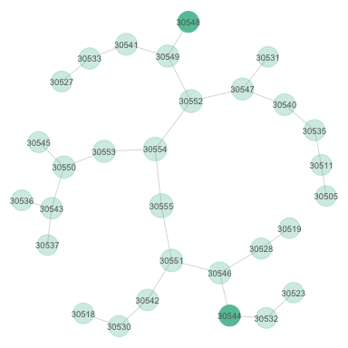

```r
hierarchy <- mwang::PlotHierarchy(clustering, model)
hierarchy$p
```

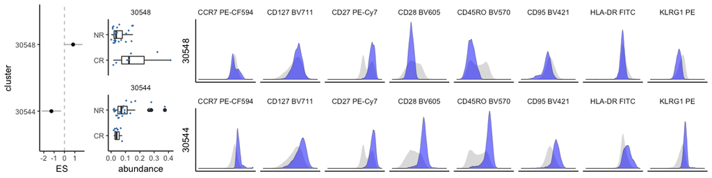

```r
res_plotlist = mwang::PlotRes(clustering, hierarchy$cluster.attributes, outcomes, channel_names_selected,
        channel_desc_selected, ylab='ES')
cowplot::plot_grid(plotlist=res_plotlist, nrow=1, rel_widths=c(1, 1, 6))
```